# How does US economy affect USF donor growth?

Yi Xie

3/30/2022

#### Analysis Plan:

Correlation Analysis and Regression Analysis: find the correlation between the USF yearly donor numbers and US economic outcomes (US GDP per Capita), Giving per USF Donors and NASDAQ performance. By doing this, we can roughly estimate or forecast the total amount we can expect and set goals for the present. Also, I want to find out what would happen to our donor growth if an economy shock happens; and what happens to US economy would negatively or positively impact the growth of USF donors.

I got the yearly donor data which contains Year, Donor Count and Total Donation Amount from the USF development side. I also got the US economic yearly data from macrotrends.net which contains Year, US GDP per Capita and Annual_Growth_rate (GDP per Capita growth rate); as well as the NASDAQ historical annual data from macrotrends.net which contains Year and Average Closing Price. Then I combined them into one table by Year, and included every data records from 1986 to now (because our giving data was not very accurate before 1986).

```r
ECON_DATA_R_raw <- read.csv("ECON_DATA_R_raw_data.csv", head=TRUE, sep=",")
ECON_DATA_R2_raw  <- ECON_DATA_R_raw[ECON_DATA_R_raw$CY >= 1986, ]
str(ECON_DATA_R2_raw)
```

```
## 'data.frame':    36 obs. of  6 variables:
##  $ CY                   : int  1986 1987 1988 1989 1990 1991 1992 1993 1994 1995 ...
##  $ DONOR_COUNT          : int  8967 8328 11556 8803 9557 8282 7951 7410 10271 10230 ...
##  $ TOTAL_AMOUNT         : num  5771501 9441848 11004319 6499870 9558842 ...
##  $ US_GDP_per_Capita    : int  19071 20039 21417 22857 23889 24342 25419 26387 27695 28691 ...
##  $ Annual_Growth_rate   : num  0.0458 0.0507 0.0688 0.0672 0.0451 0.019 0.0442 0.0381 0.0496 0.036 ...
##  $ Average_Closing_Price: num  367 403 374 438 409 ...
```

```r
summary(ECON_DATA_R2_raw)
```

```
##        CY        DONOR_COUNT     TOTAL_AMOUNT      US_GDP_per_Capita
##  Min.   :1986   Min.   : 7410   Min.   : 5771501   Min.   :19071
##  1st Qu.:1995   1st Qu.:10261   1st Qu.:12918412   1st Qu.:28442
##  Median :2004   Median :11958   Median :19726431   Median :40605
##  Mean   :2004   Mean   :11704   Mean   :19944533   Mean   :41386
##  3rd Qu.:2012   3rd Qu.:13110   3rd Qu.:24070458   3rd Qu.:51979
##  Max.   :2021   Max.   :16040   Max.   :52684024   Max.   :69738
##  Annual_Growth_rate Average_Closing_Price
##  Min.   :-0.02660   Min.   :  367.0
##  1st Qu.: 0.02917   1st Qu.:  881.8
##  Median : 0.03840   Median : 2064.5
##  Mean   : 0.03821   Mean   : 2960.7
##  3rd Qu.: 0.04965   3rd Qu.: 3601.9
##  Max.   : 0.09750   Max.   :14371.5
```

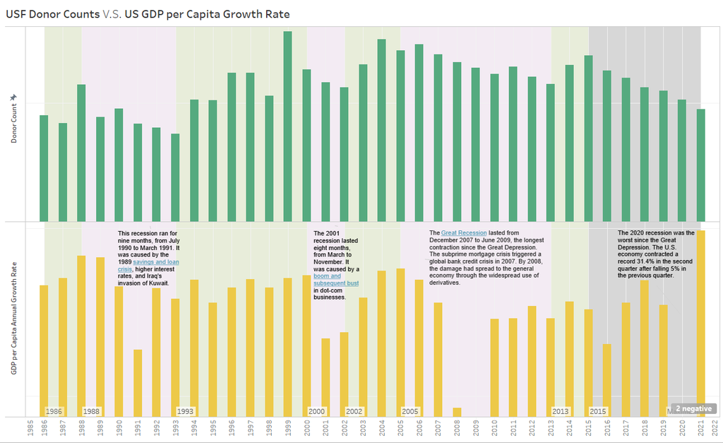

From the graph above, we can see that the trend in number of USF donors follows the US GDP per Capita Growth rate trend quite a bit. During some recessions, both have some ups and downs. So this raises the question, how exactly does GDP per capita in the US affect the number of USF donors? And how much of an impact would a positive or negative economic shock have on the number of USF donors?

```r
ECON_DATA_R <- read.csv("ECON_DATA_R.csv", head=TRUE, sep=",")
ECON_DATA_R2 <- ECON_DATA_R[ECON_DATA_R$CY >= 1986, ]
cor.test(ECON_DATA_R2$DONOR_COUNT, ECON_DATA_R2$US_GDP_per_Capita)
```

```
##
##  Pearson's product-moment correlation
##
## data:  ECON_DATA_R2$DONOR_COUNT and ECON_DATA_R2$US_GDP_per_Capita
## t = 2.5629, df = 34, p-value = 0.01498
## alternative hypothesis: true correlation is not equal to 0
## 95 percent confidence interval:
##  0.08509786 0.64557608
## sample estimates:
##       cor
## 0.4023839
```

```r
logit_model <- lm(DONOR_COUNT ~ US_GDP_per_Capita, data = ECON_DATA_R2)
summary(logit_model)
```

```
##
## Call:
## lm(formula = DONOR_COUNT ~ US_GDP_per_Capita, data = ECON_DATA_R2)
##
## Residuals:
##     Min      1Q  Median      3Q     Max
## -3908.0 -1460.1   -40.7  1408.0  4750.0
##
## Coefficients:
##                    Estimate Std. Error t value Pr(>|t|)
## (Intercept)       9.212e+03  1.029e+03   8.949 1.85e-10 ***
## US_GDP_per_Capita 6.022e-02  2.349e-02   2.563    0.015 *
## ---
## Signif. codes:  0 '***' 0.001 '**' 0.01 '*' 0.05 '.' 0.1 ' ' 1
##
## Residual standard error: 2026 on 34 degrees of freedom
## Multiple R-squared:  0.1619, Adjusted R-squared:  0.1373
## F-statistic: 6.569 on 1 and 34 DF,  p-value: 0.01498
```

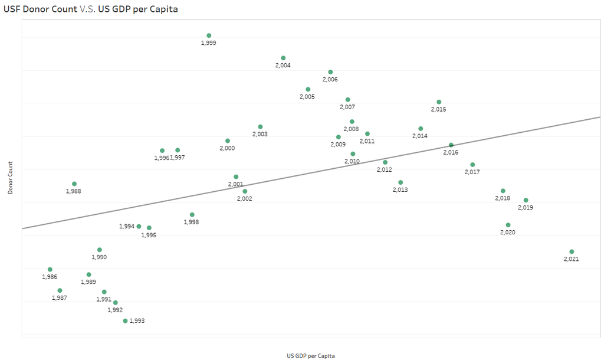

As we can see from the model above, There is some kind of correlation between USF donor numbers and US GDP per capita (with a p-value of 0.015); however, we also got a very low R-squared; which means US GDP per capita may not be the only factor to impact USF donor number. What are the other potential factors? Let’s discuss more here.

#### Progress & Visualization:

Frist, let’s see how much of an impact would a positive or negative economic shock have on the number of USF donors? I graphed the square root of USF donor count growth rate by using this formula, ((Di – D(i-1))/D(i-1))^(1/2), where Di is the total USF donor count in year I, and D(i-1) is the USF donor count in the prior year, as well as the US GDP per Capita growth rate acceleration by using this formula, (Ri – R(i-1))/R(i-1)), where Ri is the US GDP per Capita growth rate in year i. The US GDP per Capita growth rate acceleration can represent US economic shocks (positive or negative) when we see spikes on the line.

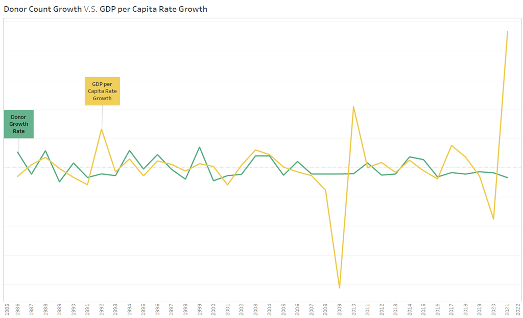

```r
cor.test(ECON_DATA_R2$sq_donor_growth_rate, ECON_DATA_R2$GDP_per_Capita_Growth_Acc)
```

```
##
##  Pearson's product-moment correlation
##
## data:  ECON_DATA_R2$sq_donor_growth_rate and ECON_DATA_R2$GDP_per_Capita_Growth_Acc
## t = 0.13486, df = 34, p-value = 0.8935
## alternative hypothesis: true correlation is not equal to 0
## 95 percent confidence interval:
##  -0.3077515  0.3490066
## sample estimates:
##        cor
## 0.02312208
```

From this correlation test, we can barely see a correlation between the USF donor growth rate and the pace of US GDP per Capita growth rate. However, from the graph above, we also can see these 2 lines lined up except at some points during the US economic shocks.

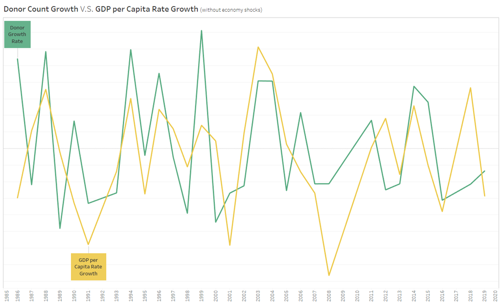

```r
ECON_DATA_R3 <- ECON_DATA_R[ECON_DATA_R$CY >= 1986 & ECON_DATA_R$CY != 1992 & ECON_DATA_R$CY != 2009 & ECON_DATA_R$CY != 2010 & ECON_DATA_R$CY != 2017 & ECON_DATA_R$CY != 2020 & ECON_DATA_R$CY != 2021, ]
cor.test(ECON_DATA_R3$sq_donor_growth_rate, ECON_DATA_R3$GDP_per_Capita_Growth_Acc)
```

```
##
##  Pearson's product-moment correlation
##
## data:  ECON_DATA_R3$sq_donor_growth_rate and ECON_DATA_R3$GDP_per_Capita_Growth_Acc
## t = 2.7114, df = 28, p-value = 0.01132
## alternative hypothesis: true correlation is not equal to 0
## 95 percent confidence interval:
##  0.1145820 0.7011088
## sample estimates:
##       cor
## 0.4560263
```

When we take out those points during the US economic shocks, the new correlation test improves the result to have a correlation score of 0.456 with a 0.01 p-value.

From the analysis above, we also can see that, shocks of the US economy actually won’t help to increase our donor growth (as fast as in the years that US economy had a constant growth); This may be due to people who were not recovered by the downfall of the economy in the previous year, and they were still in a panic mode.

So we can see that the economic shock in the US won’t affect the number of USF donors to a large extent, but what will? According to this article “Larger Donations, Fewer Donors” (https://www.insidehighered.com/news/2019/06/20/donations-colleges-are-number-donors-down), the passage of the 2017 Tax Cuts and Jobs Act, which eliminated the need for many middle-class people to itemize their deductions would largely impact the number of donors. Many have worried that, absent those itemized deductions, donations would drop. the organization’s philanthropic is disproportionately reliant on small donations from middle-income donors, who will be more affected by the tax code changes, as this is indeed the group that will move from itemized lists to non-projects, and will no longer be able to deduct charitable gifts.

```r
ECON_DATA_R2$is_shock <- ifelse(ECON_DATA_R2$CY == 1992 | ECON_DATA_R2$CY == 2009 | ECON_DATA_R2$CY == 2010 | ECON_DATA_R2$CY == 2017 | ECON_DATA_R2$CY == 2020 | ECON_DATA_R2$CY == 2021, 1, 0)
ECON_DATA_R2$after_tax_cuts <- ifelse(ECON_DATA_R2$CY >= 2017, 1, 0)
logit_model2 <- lm(DONOR_COUNT ~ US_GDP_per_Capita + is_shock + after_tax_cuts, data = ECON_DATA_R2)
summary(logit_model2)
```

```
##
## Call:
## lm(formula = DONOR_COUNT ~ US_GDP_per_Capita + is_shock + after_tax_cuts,
##     data = ECON_DATA_R2)
##
## Residuals:
##     Min      1Q  Median      3Q     Max
## -3060.2 -1016.4  -379.3  1098.2  4516.8
##
## Coefficients:
##                     Estimate Std. Error t value Pr(>|t|)
## (Intercept)        7.051e+03  9.871e+02   7.144 4.15e-08 ***
## US_GDP_per_Capita  1.296e-01  2.503e-02   5.177 1.19e-05 ***
## is_shock          -9.884e+02  8.374e+02  -1.180  0.24657
## after_tax_cuts    -3.925e+03  1.105e+03  -3.551  0.00121 **
## ---
## Signif. codes:  0 '***' 0.001 '**' 0.01 '*' 0.05 '.' 0.1 ' ' 1
##
## Residual standard error: 1652 on 32 degrees of freedom
## Multiple R-squared:  0.4755, Adjusted R-squared:  0.4263
## F-statistic: 9.669 on 3 and 32 DF,  p-value: 0.0001078
```

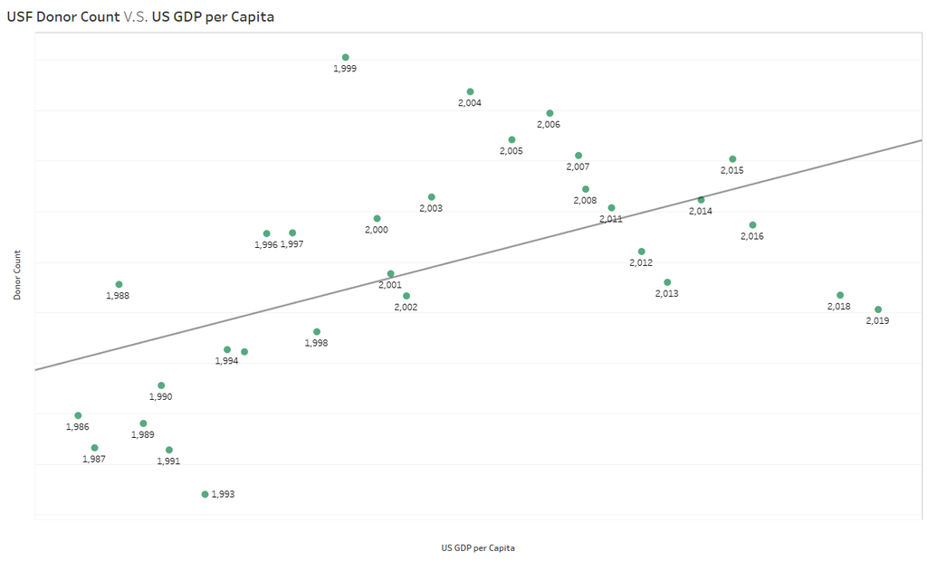

So, if we put those valuables into the model, the R-squared is improved to 0.4755 from 0.16.

#### Giving per USF Donors and NASDAQ performance

Per Give Global Blog (https://charity.org/give-global-blog/developing-your-fundraising-strategy-under-triple-threat-economic): there’s a strong relationship between how much money Americans give to charity and the stock market’s performance. That means people give more when they feel that they have money to spare. I also did a correlation analysis between Giving per USF Donors and NASDAQ performance to see if this statement is also true for USF.

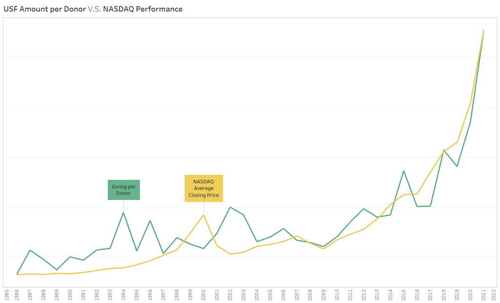

```r
ECON_DATA_R2$AMT_per_Donor <- ECON_DATA_R2$TOTAL_AMOUNT/ECON_DATA_R2$DONOR_COUNT
cor.test(ECON_DATA_R2$AMT_per_Donor, ECON_DATA_R2$Average_Closing_Price)
```

```
##
##  Pearson's product-moment correlation
##
## data:  ECON_DATA_R2$AMT_per_Donor and ECON_DATA_R2$Average_Closing_Price
## t = 14.647, df = 34, p-value = 2.999e-16
## alternative hypothesis: true correlation is not equal to 0
## 95 percent confidence interval:
##  0.8643873 0.9635164
## sample estimates:
##       cor
## 0.9290807
```

```r
logit_model2 <- lm(AMT_per_Donor ~ Average_Closing_Price, data = ECON_DATA_R2)
summary(logit_model2)
```

```
##
## Call:
## lm(formula = AMT_per_Donor ~ Average_Closing_Price, data = ECON_DATA_R2)
##
## Residuals:
##     Min      1Q  Median      3Q     Max
## -773.05 -221.86  -38.28  118.19  815.95
##
## Coefficients:
##                        Estimate Std. Error t value Pr(>|t|)
## (Intercept)           860.85841   82.02310   10.49 3.33e-12 ***
## Average_Closing_Price   0.28506    0.01946   14.65 3.00e-16 ***
## ---
## Signif. codes:  0 '***' 0.001 '**' 0.01 '*' 0.05 '.' 0.1 ' ' 1
##
## Residual standard error: 350.2 on 34 degrees of freedom
## Multiple R-squared:  0.8632, Adjusted R-squared:  0.8592
## F-statistic: 214.5 on 1 and 34 DF,  p-value: 2.999e-16
```

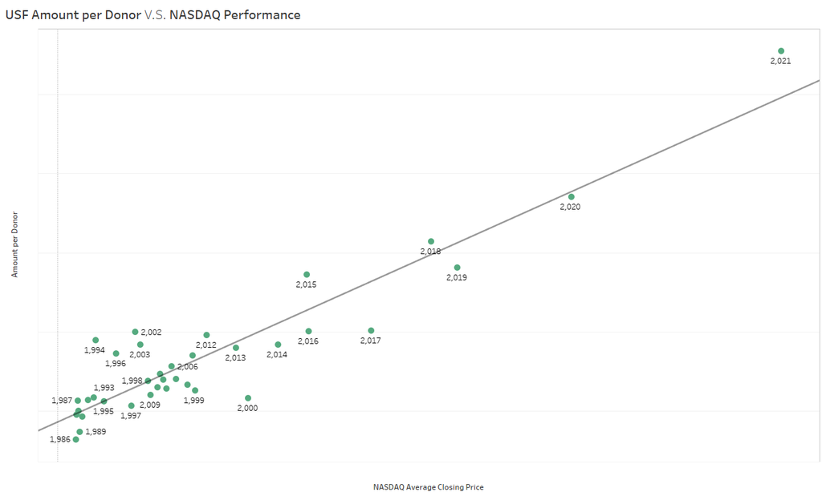

As we can see, the USF Giving per USF Donor definitely follows a linear trend with NASDAQ performance!